# Computing the Gradient

## Derivatives

- Derivatives are core to RTMB and optimization
- A derivative is the the slope (or straight line) that lies tangent to a point on a curve
- Describes the rate of change of the function at that point.

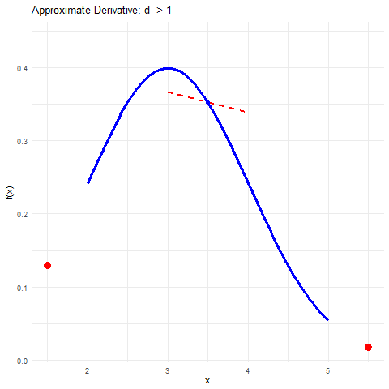

## Derivatives

- A derivative is the rate of change of a function $f$ with respect to $x$, for some small $\Delta$,

$$\frac{df}{dx} \approx \frac{f(x + \Delta) - f(x)}{\Delta}$$

- Calculus definition is when $\lim_{\Delta \to 0}$
- The maximum/minimum is when the slope is flat, or $\frac{df}{dx} = 0$

## Derivatives

- The derivative changes depending on the value of $x$,

$$\begin{aligned}
f(x) & = 3 - 3x - (x-5)^2\\
\frac{df}{dx} &= - 3 - 2(x-5)
\end{aligned}$$

- Optimization is simply finding where the derivative is zero,

$$\begin{aligned}
\frac{df}{dx} & = 0\\
- 3 - 2(x-5) & = 0 \\
x & = -3/2 + 5 \\
x & = 3.5
\end{aligned}$$
- We can do this numerically in R.

```r
max_x <- optimise(f=\(x){3-3*x -(x-5)^2}, maximum = TRUE, interval = c(-10, 10))
max_x$maximum
```

```
[1] 3.5
```

## Derivatives

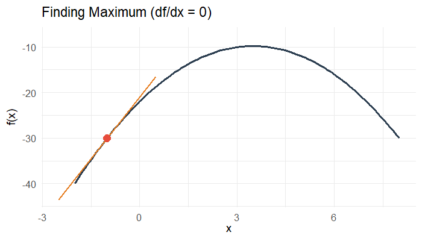

## Gradient

- Derivative in multiple dimensions (referred to as ‘partial derivatives’) and $df$ becomes $\partial f$,

$$\frac{\partial f(x,y)}{\partial x} = \lim_{\Delta \to 0} \frac{f(x + \Delta, y) - f(x,y)}{\Delta}.$$

- Gradient is the vector of the partial derivatives,

$$\nabla f(x,y) = \Big\{ \frac{\partial f(x,y)}{\partial x}, \frac{\partial f(x,y)}{\partial y} \Big\}$$

- Minimization/maximization is where gradient is zero (i.e. all partial derivatives are zero)

## Second Derivative

- Second derivatives tell us the rate of change of the derivative.
- Simply the derivative of the derivative $\frac{d^2f}{dx^2}$

$$\frac{d^2f}{dx^2} \approx \frac{f(x+\Delta) - 2f(x) + f(x-\Delta)}{\Delta^2}$$

- Classify the stationary point:
  - *Minimum* Positive (Increasing at an increasing rate)
  - *Maximum* Negative (Increasing at a decreasing rate)

$$\begin{aligned}
f(x) & = 3 - 3x - (x-5)^2\\
\frac{df}{dx} & = - 3 - 2(x-5)\\
\frac{d^2f}{dx^2} & = -2
\end{aligned}$$

- Can tell that this polynomial is ‘concave’ or faces downward.
- Therefore, we know that when $\frac{df}{dx} = 0$ we have found the maximum!

## Hessian Matrix

- Hessian is matrix of all second partial derivatives

$$H_f = \nabla^2 f(x,y) = \begin{bmatrix}
\frac{\partial^2 f}{\partial x^2} & \frac{\partial^2 f}{\partial x \partial y} \\
\frac{\partial^2 f}{\partial y \partial x} & \frac{\partial^2 f}{\partial y^2}
\end{bmatrix}$$

- Classify the stationary point:
  - Positive-definite means *Minimum*
  - Negative-definite means *Maximum*
- Variance is inverse of negative Hessian of log-likelihood.
- If Hessian isn’t positive-definite, can’t calculate variance (check that every eigenvalue is positive).

## Gradients in R

- Finite differences to compute the derivative
- Compute function at nearby points and compute slope (central difference),
  $$\frac{\partial f}{\partial x} \approx \frac{f(x+\Delta, y) - f(x-\Delta,y)}{2\Delta}.$$
- Numerical error can be significant
- Computation is slow due to the number of different calls to the function

```r
f <- \(x){
  count <<- count + 1
  3-3*x - (x-5)^2
}
df <- \(x){-3 -2*(x-5)}   ## Derivative

df(0)
```

```
[1] 7
```

```r
count <- 0
pracma::jacobian(f, 0)
```

```
     [,1]
[1,]    7
```

```r
cat("Number of times f is called by finite differences:", count, "\n")
```

```
Number of times f is called by finite differences: 3
```

## RTMB

- Take base R code and pass it to TMB’s numerical machinery
- RTMB couples R directly to TMB’s automatic- differentiation engine
- Code in C++ is generally faster than in R
- Automatic Differentiation (AD) is the computation of the ‘chain rule’ to compute gradients
- Each computation within the tape that doesn’t change is pre-computed
- AD gives numerical gradients with analytical precision

## Gradients in RTMB

- Automatic Differentiation starts with ‘taping’

```r
library(RTMB)

# f <- \(x){ 3-3*x - (x-5)^2}
fc <- RTMB::MakeTape(f, 0)    ## Evaluates in C++
fc$print()
```

```
OpName:  Node:       Value:       Deriv:       Index:    Inputs:
  InvOp      0            0           NA            0
ConstOp      1            3           NA            1
  MulOp      2            0           NA            2    0 1
ConstOp      3            3           NA            3
  SubOp      4            3           NA            4    3 2
ConstOp      5            5           NA            5
  SubOp      6           -5           NA            6    0 5
ConstOp      7            2           NA            7
  PowOp      8           25           NA            8    6 7
  SubOp      9          -22           NA            9    4 8
  DepOp     10          -22           NA           10    9
```

- `inv` (`InvOp`) Independent variable (operator)
- `const` Constant
- `dep` (`DepOp`) Dependent variable (operator)

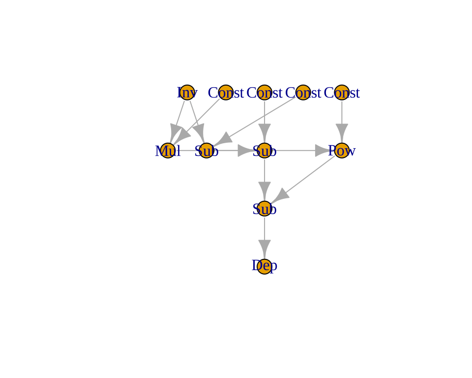

## Gradients in RTMB

- AD is faster and more accurate than finite differences

```r
f <- \(x){3-3*x -(x-5)^2}
df <- \(x){-3 -2*(x-5)}   ## Derivative
d2f <- \(x){-2}           ## Second Derivative

fc <- RTMB::MakeTape(f, 0)    ## Evaluates in C++
dfc <- fc$jacfun()            ## Create a derivative function
d2fc <- dfc$jacfun()          ## Create a derivative of derivative function

pracma::jacobian(f, 0) - dfc(0)
```

```
             [,1]
[1,] 1.648734e-10
```

```r
dfc(0) - df(0)
```

```
     [,1]
[1,]    0
```

```r
pracma::hessian(f, 0) - d2fc(0)
```

```
     [,1]
[1,]    0
```

```r
d2fc(0) - d2f(0)
```

```
     [,1]
[1,]    0
```

## Ricker Example

- Stock ($s$) specific productivity, carrying capacity, and standard deviation,
  $$\log(R_i/S_i) = \alpha_{s_i} - \beta_{s_i}S_i + \epsilon_i.$$

```r
sox$stock <- as.numeric(factor(sox$PopName))
nstocks <- max(sox$stock)
set.seed(1)   ## random but reproducible starting values, in a plausible range
parameters <- list(
  alpha = runif(nstocks, 1, 3),
  logbeta = runif(nstocks, -1, 0),
  logsigma = runif(nstocks, -0.5, 0.5)
)

sox$logRS <- log(sox$recruits/sox$spawners)

negll <- function(pars){
  getAll(pars)
  beta <- exp(logbeta)
  sigma <- exp(logsigma)
  mu <- alpha[sox$stock] - beta[sox$stock]*sox$spawners_scaled
  -sum(dnorm(sox$logRS, mu, sigma[sox$stock], log = TRUE))
}
obj <- MakeADFun(func = negll, parameters = parameters, silent = TRUE)
```

## RTMB Speed Up

- Function evaluation

```r
microbenchmark::microbenchmark(
  "R" = negll(parameters),
  "RTMB" = obj$fn(obj$par+rnorm(1,0,0.1)) ## Caches last call so need to perturb
)
```

```
Unit: microseconds
 expr    min      lq      mean  median      uq       max neval
    R 62.708 66.9060 273.90182 70.9695 80.8325 19297.599   100
 RTMB 38.670 40.9705  52.34425 43.7975 49.8215   265.316   100
```

- Gradient Evaluation

```r
count <- 0
negll_vec <- \(pars){
  params <- obj$env$parList(pars)
  count <<- count + 1
  negll(params)
}
gr <- pracma::jacobian(negll_vec, obj$par)
print(count)
```

```
[1] 115
```

```r
microbenchmark::microbenchmark(
  "R" = pracma::jacobian(negll_vec, obj$par),
  "RTMB" = obj$gr(obj$par + rnorm(1, 0, 0.1)),
  times = 10
)
```

```
Unit: microseconds
 expr       min        lq       mean     median        uq       max neval
    R 16260.931 16684.776 17637.8620 17211.7225 17378.339 23304.162    10
 RTMB   107.444   113.413   232.7917   198.0315   221.669   813.028    10
```

## RTMB Hessian

- Finite differences approximate the gradient by evaluating function nearby and computing slope.
- Requires multiple function evaluations for each parameter
- Hessian requires even more evaluations with additional numerical error
- Accurate and fast Hessian required for standard errors
- Hessian critical to marginalize random effects (discuss later)

```r
count <- 0
gr <- pracma::hessian(negll_vec, obj$par)
print(count)
```

```
[1] 6556
```

## Practical

- Make sure your Ricker model gradient is computing correctly.
- Compare your versions with `RTMB` and `R`
- Try comparing AD gradient `obj$gr` with finite differences `pracma::jacobian`
- Try comparing AD Hessian `obj$he` with finite differences `pracma::hessian`

## Optimization in R

- Random start, evaluate objective function, use gradient to move to new value
- Run until at maximum/minimum (where gradient is zero)
- Gradient-based optimizers: `nlminb`, or `optim(method = "BFGS")` (the `optim` default, Nelder-Mead, uses no gradient)
- If gradient not provided, then finite differences are used.

```r
set.seed(24)
x <- rnorm(100, 0.25, 2)
nll <- \(pars){
  mu <- pars[1]
  sigma <- exp(pars[2])
  -sum(dnorm(x, mu, sigma, log = TRUE))
}

# optim(c(0,0), nll)
nlminb(c(0,0), nll)
```

```
$par
[1] 0.002335921 0.634946290

$objective
[1] 205.3885

$convergence
[1] 0

$iterations
[1] 10

$evaluations
function gradient
      13       26

$message
[1] "relative convergence (4)"
```

## Optimization in R

- What about more than one peak? (Multimodality)
- Derivative is zero at more than one place
- Want ‘global’ maximum
- Random starting points are critical
- If likelihood is multimodal there are likely other things wrong
- As we get more data, the likelihood becomes more smooth and ‘peaky’

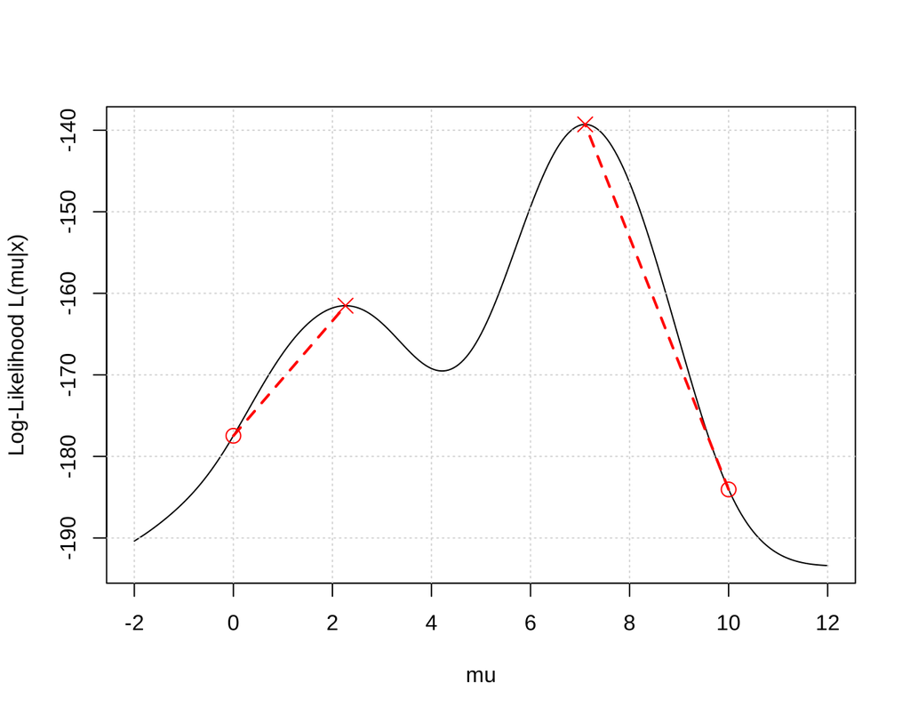

## Fitting the MLE

```r
par_init <- obj$par + rnorm(length(obj$par), 0, 0.5)
## nlminb stops after 150 iterations by default: give it room
mle <- nlminb(par_init, obj$fn, obj$gr, control = list(eval.max = 1e4, iter.max = 1e4))
mle$message
```

```
[1] "relative convergence (4)"
```

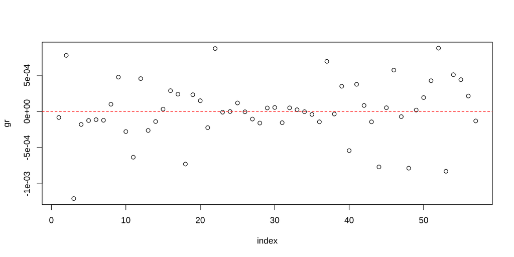

```r
plot(t(obj$gr(mle$par)), ylab = "gr", xlab = "index")
abline(h = 0, col = 'red', lty = 2)
```

## End of Module

- Take home:
  - Gradient is critical for optimization
  - Need Hessian to check optimization and compute variance
  - RTMB makes it really easy and fast to compute gradients
- Questions?